# Labor Market Discrimination

Labour Economics, ECON207 — UG-II, 2026: Semester IV

Ravikiran Naik

Department of Economics, FLAME University

April 2026

## Sections Covered

| § | Topic |
| --- | --- |
| 9-1 | Race and Gender in the Labor Market |
| 9-2 | The Discrimination Coefficient |
| 9-3 | Employer Discrimination |
| 9-4 | Employee Discrimination |
| 9-5 | Customer Discrimination |
| 9-6 | Statistical Discrimination |
| 9-8 | Measuring Discrimination |
| 9-9 | Policy: The Black–White Wage Gap |
| 9-10 | The Relative Wage of Hispanics and Asians |
| 9-11 | Policy: The Male–Female Wage Gap |

## What Is Labor Market Discrimination?

- Discrimination occurs when the marketplace takes into account factors such as **race, sex, caste, or appearance** when making economic exchanges.
- These factors are **not related to productivity** — yet they affect hiring, wages, and occupational sorting.
- The central question: how much of the observed wage gap between groups reflects **skill differences** and how much reflects **discrimination**?

## Types of Discrimination

**Discriminatory Behaviours** *(Oxford English Dictionary)*

- **Ableism** — discrimination in favour of able-bodied persons.
- **Ageism** — prejudice or discrimination on the grounds of age, especially against the elderly.
- **Fattism** — prejudice or discrimination against fat people.
- **Heterosexism** — prejudice and antagonism by heterosexual persons toward homosexuals.
- **Lookism** — prejudice or discrimination on the grounds of appearance.
- **Racism** — hatred or intolerance of another race or other races.
- **Sexism** — discrimination or devaluation based on a person’s sex, especially directed against women.

## Race and Gender in the Labor Market

- Men earn more than women, and whites usually earn more than non-whites — these are **raw wage differentials**.
- Differences in **educational attainment** between whites and non-whites account for a **portion** of the wage differential — but not all of it.
- After controlling for education, experience, occupation, and region, a **residual gap** remains — this residual is often attributed to discrimination.
- The key empirical challenge is **decomposing** the raw gap into an **explained** portion (skills) and an **unexplained** portion (discrimination).

## What Is the Discrimination Coefficient?

- **Gary Becker (1957)** formalised the notion of **taste-based discrimination** — racial prejudice translated into economic behaviour.
- A prejudiced employer perceives the cost of hiring a Black worker as **higher than the true cost**.
- Even though it costs $w_B$ dollars to hire one person-hour of Black labour, the employer acts as if it costs $w_B(1 + d)$, where $d > 0$ is the **discrimination coefficient**.
- A larger $d$ means **more prejudice**: the employer requires a bigger wage discount before willingly hiring Black workers.

## How Does a Non-Discriminating Firm Hire?

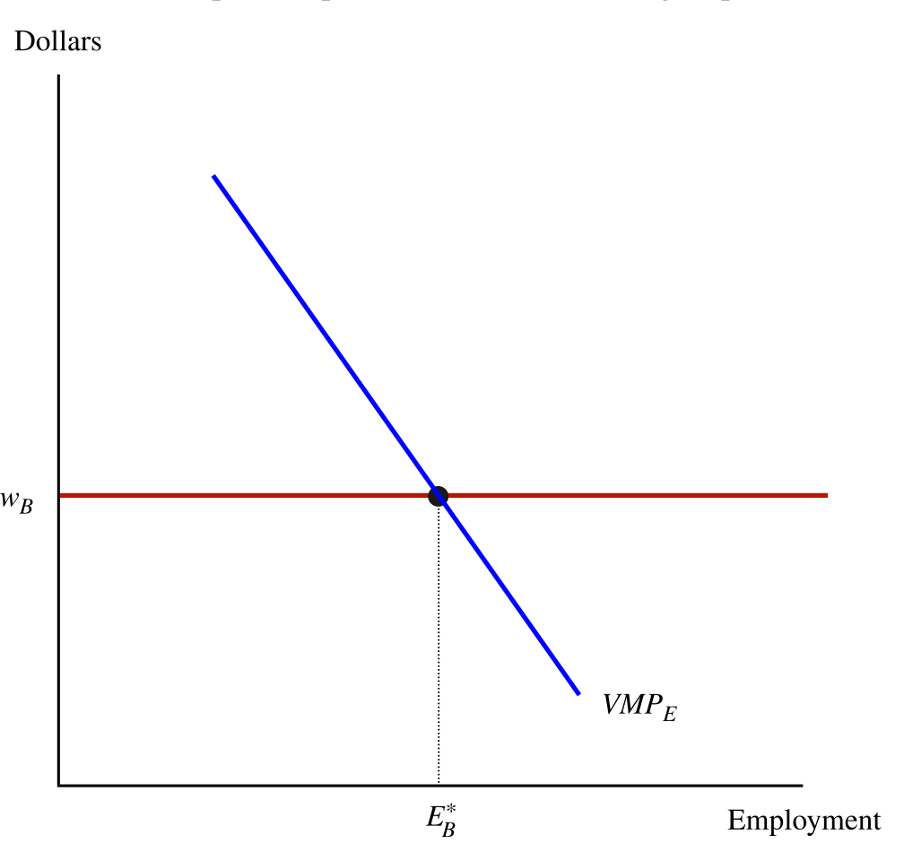

*Figure 9-1: The Hiring Decision of a Firm That Does Not Discriminate*

## How Does a Prejudiced Firm Hire?

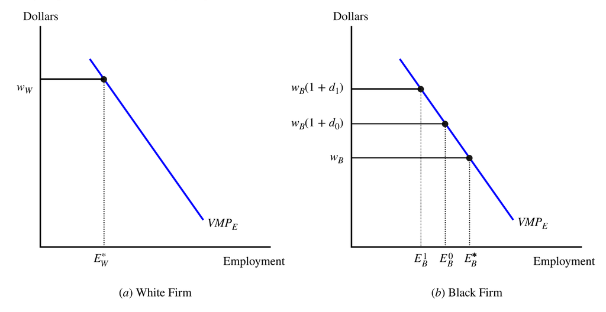

*Figure 9-2: The Hiring Decision of a Prejudiced Firm*

## Employer Discrimination: Key Implications

- If Black and white workers are **perfect substitutes**, the Becker model predicts **segregated workforces**: each firm hires only one race.
- Even **non-discriminating employers** end up with a segregated (all-Black) workforce — they hire the cheaper, equally productive group.
- **Discrimination does not pay**: prejudiced employers hire the wrong type of worker and/or the wrong number of workers — reducing their **profits**.
- In **competitive markets**, discriminating firms earn lower profits and should eventually be **driven out** by non-discriminating competitors.

## Profits and Discrimination

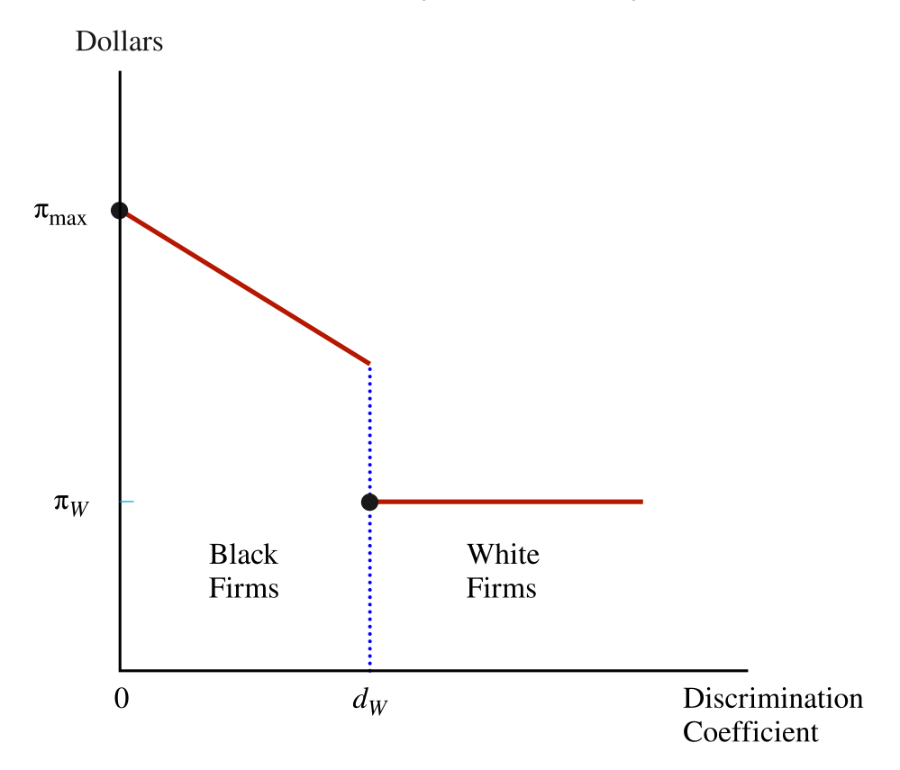

*Figure 9-3: Profits and the Discrimination Coefficient*

## Determination of the Relative Minority Wage

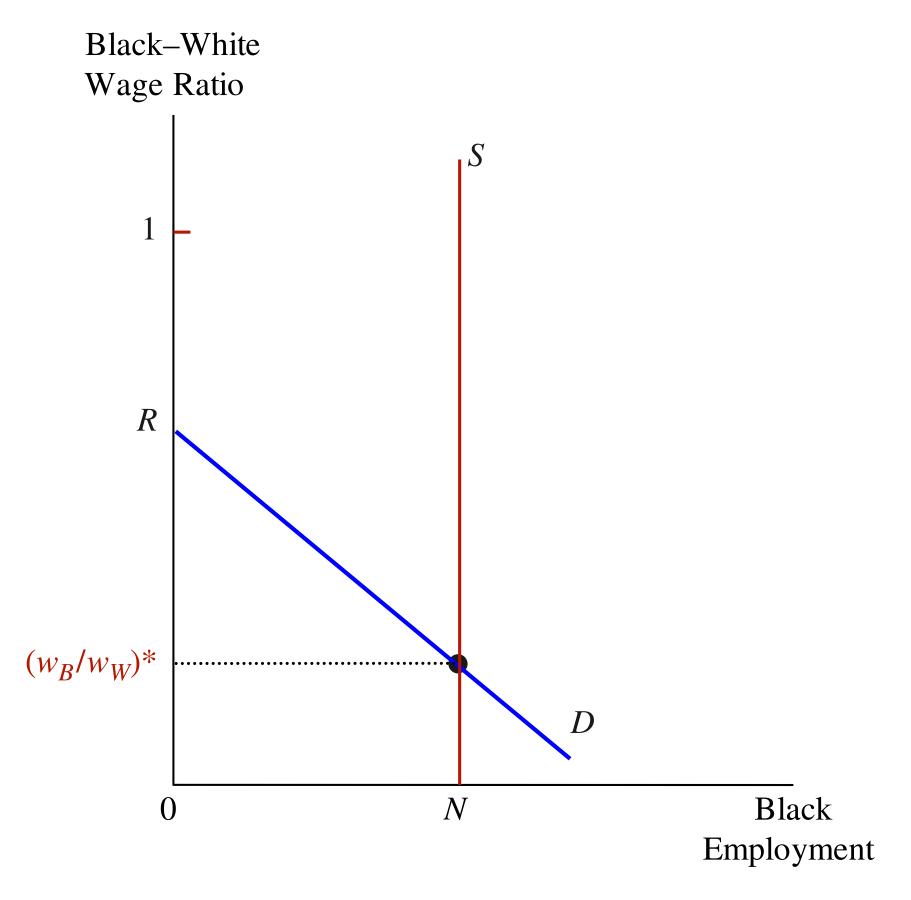

*Figure 9-4: Determination of the Relative Minority Wage in the Labor Market*

## When Some Firms Have Negative Discrimination Coefficients

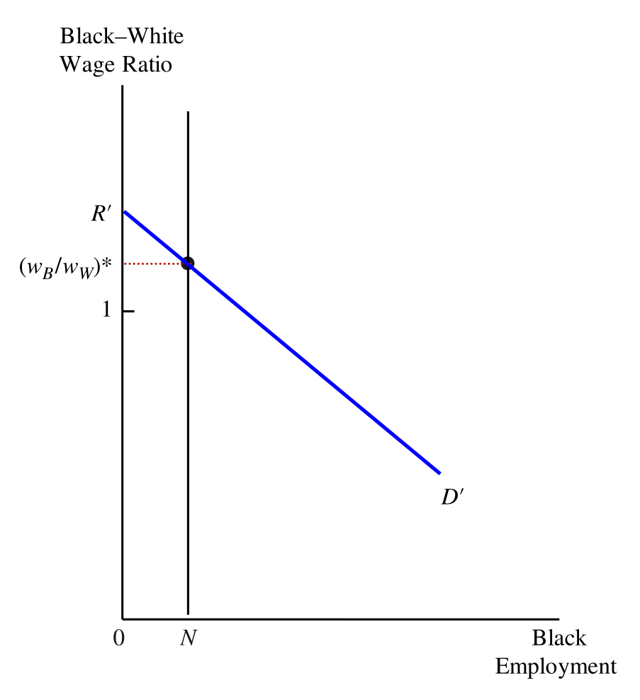

*Figure 9-5: The Relative Minority Wage When Some Firms Have Negative d*

## Employee Discrimination

- **Employee discrimination**: white workers dislike working alongside Black workers — they require a **compensating differential** (higher wage) to do so.
- **Key result**: employee discrimination does **not** generate a wage differential between equally skilled Black and white workers.
- Employee discrimination does **not affect** the profitability of firms — the cost is borne by prejudiced workers themselves (they sort into segregated workplaces).
- The outcome is **workplace segregation**: Black and white workers end up in different firms, but at the same wage.

## Customer Discrimination

- If customers discriminate, their perceived price of a good is **utility-adjusted** with a discrimination coefficient: they act as if the price is $p(1 + d_c)$ when served by a Black worker.
- When a firm **cannot hide** Black workers from customers, customer discrimination can have an **adverse effect on Black wages**.
- Customer discrimination is most relevant in **customer-facing** occupations (sales, services, professional consultations).
- Firms may respond by assigning minority workers to **back-office** roles — creating **occupational segregation** even within firms.

## What Is Statistical Discrimination?

- **Statistical discrimination** occurs when employers base decisions on the **average characteristics** of the group to which a worker belongs.
- Employers use **imperfect predictors of productivity**: age, education, and experience provide some information — but not enough.
- Employers may use **race and gender as well**, since these also provide statistical information about group averages.
- **Example**: young males pay higher car insurance rates because, **on average**, they have more accidents — even though many individual young men are safe drivers.

## Statistical Discrimination: The Mechanism

- Gender may provide information on **job commitment** since women on average have **higher turnover rates**.
- Race may provide information about **schooling quality** since Black workers on average attended **lower-quality schools** than white workers.
- The employer is not being **malicious** — they are using all available information to minimise **hiring costs**.
- The **problem**: workers whose individual characteristics differ from the group average are **harmed** — a high-commitment woman or a well-educated Black worker is judged by the group mean, not their own traits.

## Statistical Discrimination: Implications

- Employers are **not harmed** when they practise statistical discrimination — they **gain** since they minimise hiring costs.
- Statistical discrimination will **diminish** if the average characteristics of the groups **converge** over time.
- Male-female **turnover rates are converging** — this should reduce gender-based statistical discrimination.
- **Policy challenge**: banning the use of group characteristics (e.g., race or gender) in hiring forces employers to use **less informative signals** — but it protects individuals from being judged by group averages.

## Impact of Statistical Discrimination on Wages

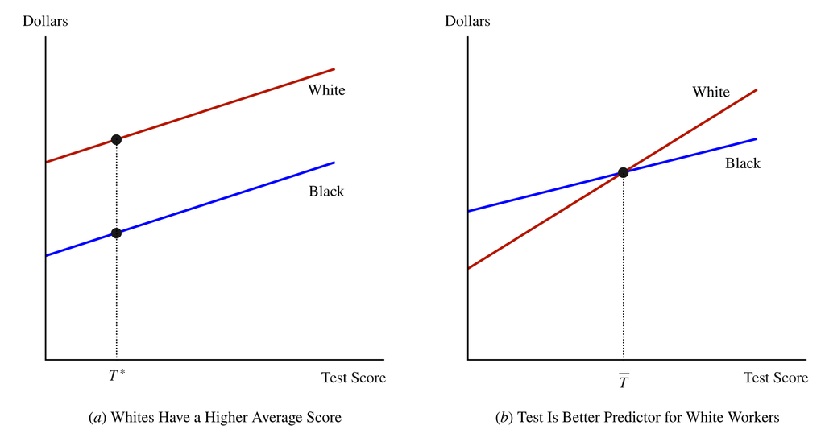

*Figure 9-6: Statistical Discrimination and Wages*

## Non-Discrimination Factors

- Raw racial and gender differentials in earnings, occupational distribution, and unemployment must be interpreted with **caution**.
- Factors **other than discrimination** may play a role:
- **Individual choice**: women may choose occupations with greater flexibility for family responsibilities.
- **Pre-market human capital**: differences in schooling quality, field of study, and work experience.
- The challenge is separating **constrained choices** (driven by discrimination or social norms) from **free choices** (driven by genuine preferences).

## How Do We Measure Discrimination?

- One possible measure is the **difference in mean wages** — but this confounds discrimination with skill differences.
- A better measure would compare the wages of **equally skilled workers** from different groups.
- The **Oaxaca decomposition** (1973): a technique that decomposes the raw wage differential into:
- A portion related to **differences in skills** (explained component).
- A portion attributable to **labour market discrimination** (unexplained component).

## The Oaxaca–Blinder Decomposition

- **Raw wage gap**: $\Delta w = \color{#0000DC}{\bar{w}_M} - \color{#F01928}{\bar{w}_F}$ — **“comparing apples and oranges”** (confounds skills with discrimination).
- Estimate **separate earnings functions** for each group:
  $$\color{#0000DC}{w_M = \alpha_M + \beta_M\, s_M} \qquad \color{#F01928}{w_F = \alpha_F + \beta_F\, s_F}$$
- No discrimination: $\alpha_M = \alpha_F$ and $\beta_M = \beta_F$ — employers value skills **equally**.
- **Decomposition** (Eq. 9-8):
  $$\Delta w = \underbrace{\left\{(\alpha_M - \alpha_F) + (\beta_M - \beta_F)\bar{s}_F\right\}}_{\color{#F01928}{\text{Due to discrimination}}} + \underbrace{\beta_M(\bar{s}_M - \bar{s}_F)}_{\color{#0000DC}{\text{Due to skills}}}$$

## Statistical Discrimination and Wages

- The firm’s wage offer is a **weighted average** of the applicant’s own score $\color{#0000DC}{T}$ and the group average $\color{#F01928}{\bar{T}}$:
  $$w = (1 - \alpha)\,\color{#F01928}{\bar{T}} + \alpha\,\color{#0000DC}{T}$$
- $\alpha = 1$: test **perfectly predicts** — wage depends only on own score; $\alpha = 0$: own score **meaningless** — employer relies entirely on group average.
- $\alpha$ = **predictive power** of the screening test — higher $\alpha$ means less reliance on group membership.
- Statistical discrimination affects **both the intercept and the slope** of the wage–test-score line.

## Measuring Gender Discrimination on Wages

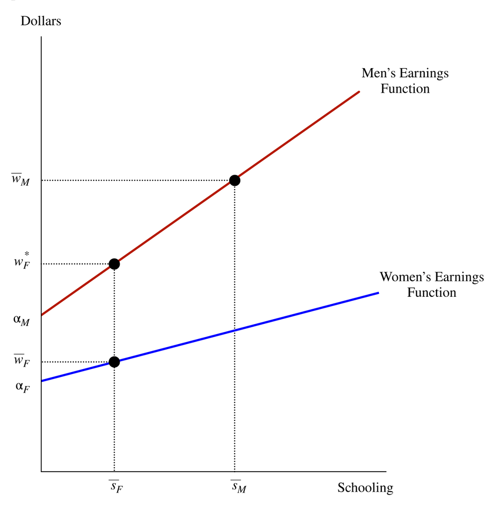

*Figure 9-7: Measuring the Impact of Discrimination on the Wage*

## Trend in Black–White Earnings Ratio, 1967–2020

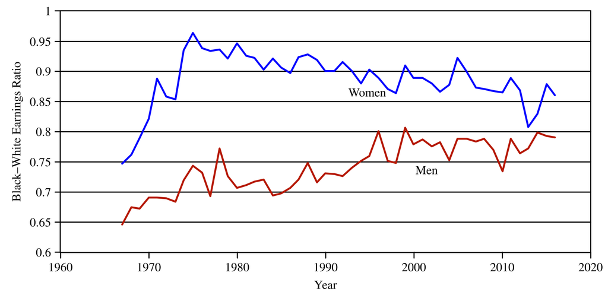

*Figure 9-8: Trend in Black–White Earnings Ratio, 1967–2020*

## Male LFP Rates, by Race, 1955–2020

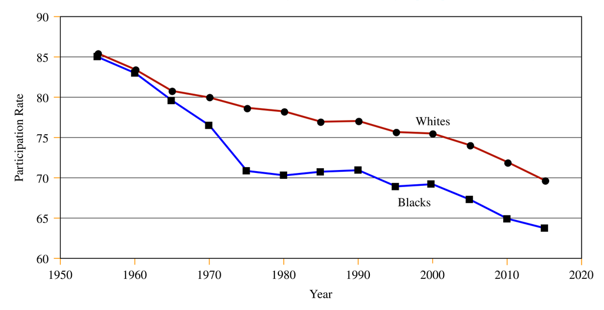

*Figure 9-9: Male Labor Force Participation Rates, by Race, 1955–2020*

## The Decline in Black LFP and the Average Black Wage

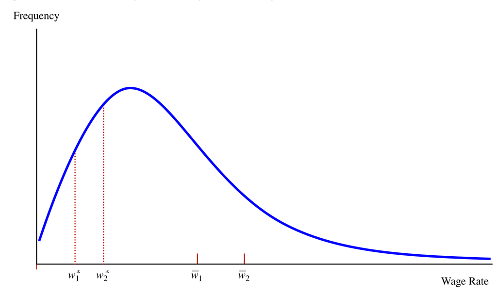

*Figure 9-10: Decline in Black Labor Force Participation and the Average Black Wage*

## Trend in Relative Earnings of Hispanics and Asians, 1974–2020

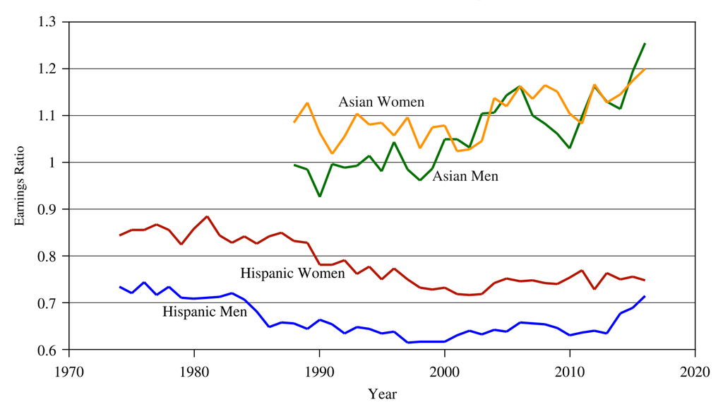

*Figure 9-11: Trend in Relative Earnings of Hispanics and Asians, 1974–2020*

## Determinants of the Male–Female Wage Ratio

- **Occupational crowding** has segregated women into particular occupations where the return to education is **lower**.
- Human capital is more profitable the **longer the payoff period** — women who anticipated career interruptions historically invested in occupations with **lower depreciation rates**.
- Women are better off if they enter occupations in which their skills **do not deteriorate** during years spent in the household sector.
- The gender wage gap has narrowed substantially since 1980, driven by **rising female education**, **delayed fertility**, and **changing occupational choices**.

## Trend in Female–Male Earnings Ratio, 1960–2020

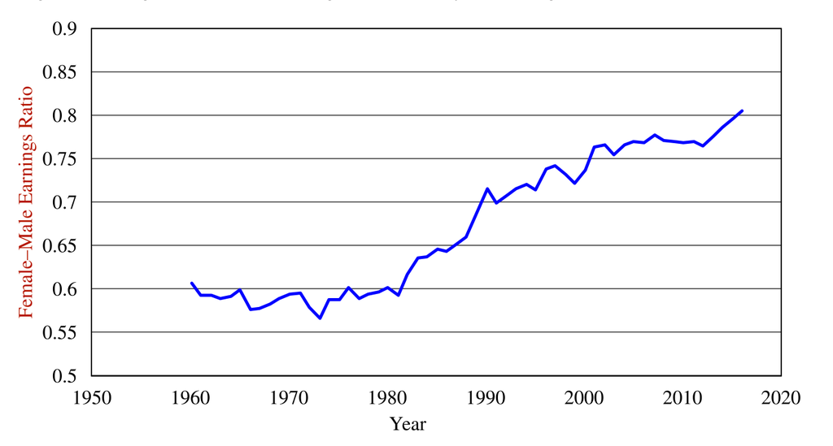

*Figure 9-12: Trend in Female–Male Earnings Ratio, 1960–2020*

## Review — Introduction

- Discrimination occurs when the marketplace accounts for factors (race, sex, caste) unrelated to productivity.
- Raw wage differentials between groups partly reflect skill differences and partly reflect discrimination.
- The empirical challenge is decomposing the gap into explained (skills) and unexplained (discrimination) components.

## Review — Taste Discrimination (Becker)

- The **discrimination coefficient** $d$ makes the employer perceive minority labour as costing $w_B(1+d)$ rather than $w_B$.
- With perfect substitutes, the Becker model predicts segregated workforces — each firm hires only one race.
- Discrimination is costly: prejudiced firms earn lower profits and should be driven out by competitive forces.
- Persistence of discrimination suggests imperfect competition or non-employer sources of prejudice.

## Review — Employee, Customer & Statistical Discrimination

- **Employee discrimination** produces workplace segregation but not wage gaps.
- **Customer discrimination** creates wage gaps in customer-facing occupations; competitive forces cannot easily eliminate it.
- **Statistical discrimination** is rational but unfair: employers judge individuals by group averages when individual signals are noisy.
- Statistical discrimination diminishes as group characteristics converge.